# Introduction to the Tidyverse

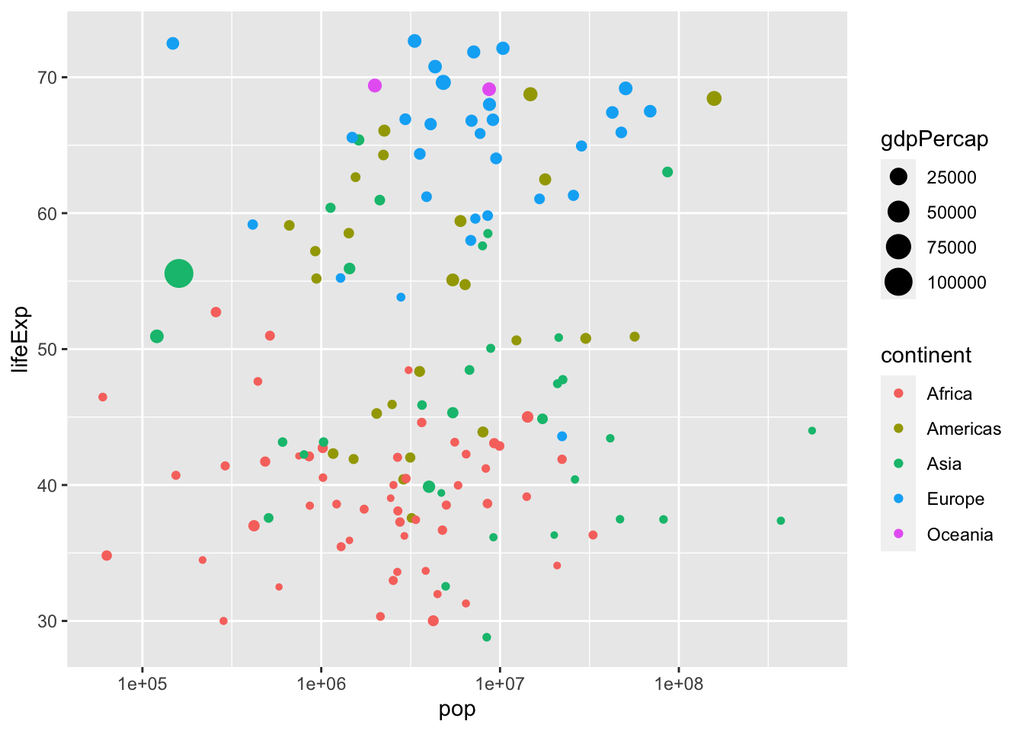

```r
#size
# Add the size aesthetic to represent a country's gdpPercap
ggplot(gapminder_1952, aes(x = pop, y = lifeExp, color = continent,size=gdpPercap)) +
  geom_point() +
  scale_x_log10()
```

Visualizing data by categorical variables by using `facet_wrap()`:  
ggplot2 lets you divide your plot into subplots to get one smaller graph for each categories, it’s another powerful way to communicate relationships within your data.

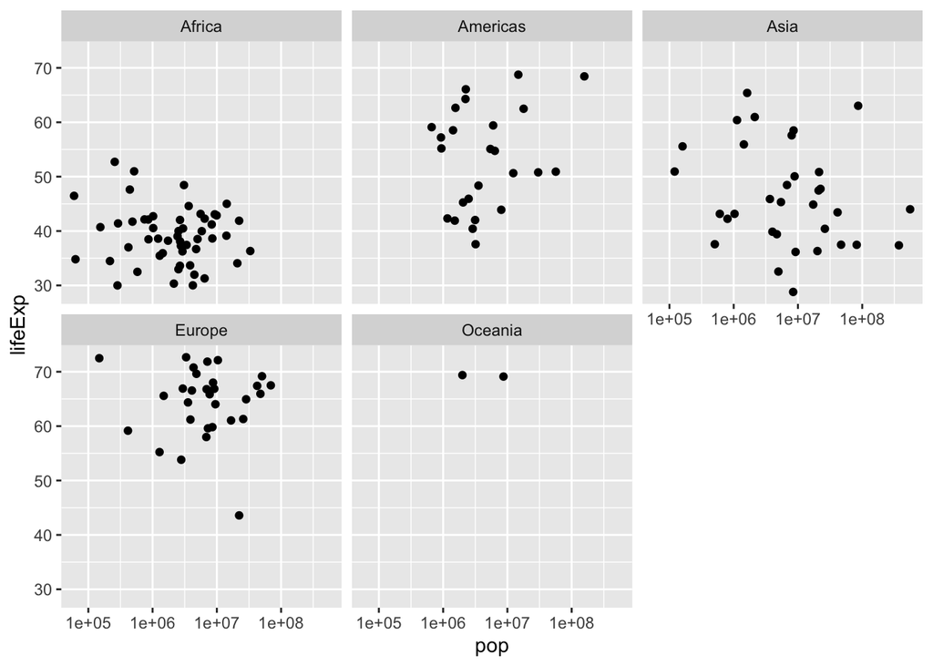

```r
# Scatter plot comparing pop and lifeExp, faceted by continent
ggplot(gapminder_1952,aes(x=pop,y=lifeExp)) +
  geom_point() +
  scale_x_log10() +
  facet_wrap(~continent)
```

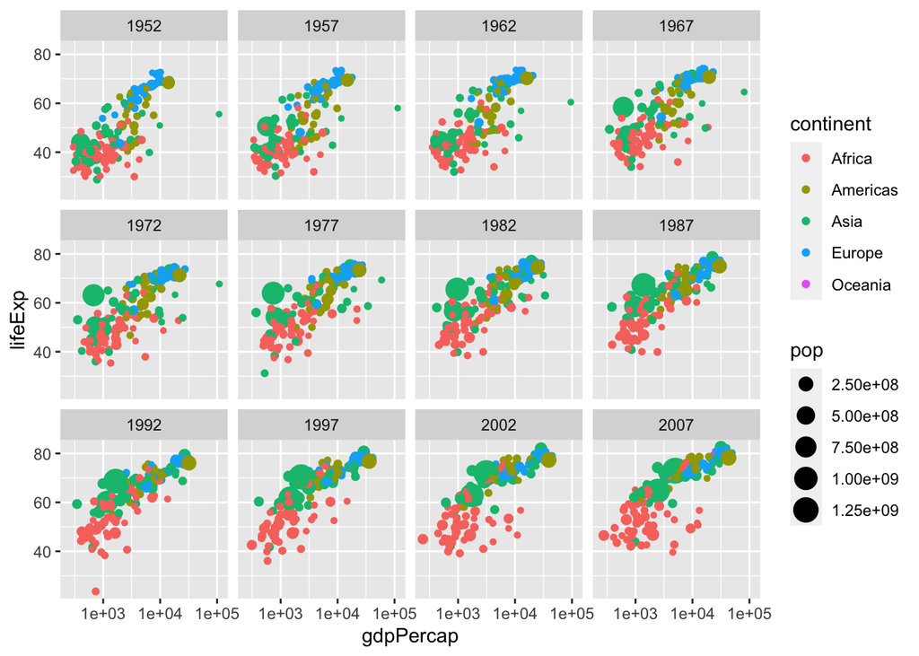

```r
#faceting by year
# Scatter plot comparing gdpPercap and lifeExp, with color representing continent
# and size representing population, faceted by year
ggplot(gapminder,aes(x=gdpPercap,y=lifeExp,color=continent,size=pop)) +
 geom_point() +
 scale_x_log10() +
 facet_wrap(~year)
```

## Grouping and Summarizing

```r
library(gapminder)
library(dplyr)
#summarize() function
# Summarize to find the median life expectancy
gapminder %>%
  summarize(medianLifeExp=median(lifeExp))
```

```
## # A tibble: 1 × 1
##   medianLifeExp
##           <dbl>
## 1          60.7
```

```r
# Filter for 1957 then summarize the median life expectancy and the maximum GDP per capita
gapminder %>%
  filter(year==1957)  %>%
  summarize(medianLifeExp=median(lifeExp),
            maxGdpPercap=max(gdpPercap))
```

```
## # A tibble: 1 × 2
##   medianLifeExp maxGdpPercap
##           <dbl>        <dbl>
## 1          48.4      113523.
```

`group_by()`: summarizing data in groups

```r
# Find median life expectancy and maximum GDP per capita in each continent in 1957
gapminder  %>%
  filter(year==1957) %>%
  group_by(continent) %>%
  summarize(medianLifeExp=median(lifeExp),
            maxGdpPercap=max(gdpPercap))
```

```
## # A tibble: 5 × 3
##   continent medianLifeExp maxGdpPercap
##   <fct>             <dbl>        <dbl>
## 1 Africa             40.6        5487.
## 2 Americas           56.1       14847.
## 3 Asia               48.3      113523.
## 4 Europe             67.6       17909.
## 5 Oceania            70.3       12247.
```

```r
#group by two variables combined
# Find median life expectancy and maximum GDP per capita in each continent/year combination
gapminder  %>%
  group_by(continent,year) %>%
  summarize(medianLifeExp=median(lifeExp),
            maxGdpPercap=max(gdpPercap))
```

```
## # A tibble: 60 × 4
## # Groups:   continent [5]
##    continent  year medianLifeExp maxGdpPercap
##    <fct>     <int>         <dbl>        <dbl>
##  1 Africa     1952          38.8        4725.
##  2 Africa     1957          40.6        5487.
##  3 Africa     1962          42.6        6757.
##  4 Africa     1967          44.7       18773.
##  5 Africa     1972          47.0       21011.
##  6 Africa     1977          49.3       21951.
##  7 Africa     1982          50.8       17364.
##  8 Africa     1987          51.6       11864.
##  9 Africa     1992          52.4       13522.
## 10 Africa     1997          52.8       14723.
## # … with 50 more rows
```

Visualizing summarized data

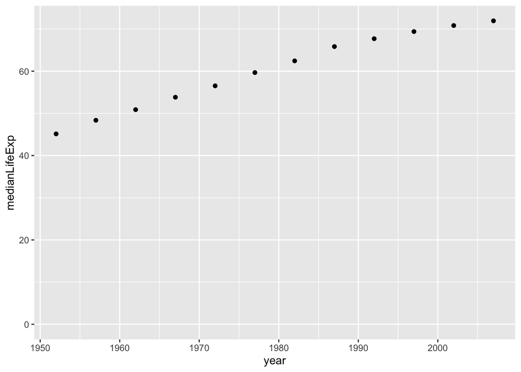

```r
by_year <- gapminder %>%
  group_by(year) %>%
  summarize(medianLifeExp = median(lifeExp),
            maxGdpPercap = max(gdpPercap))

# Create a scatter plot showing the change in medianLifeExp over time
#Be sure to add expand_limits(y = 0) to make sure the plot's y-axis includes zero
ggplot(by_year,aes(x=year,y=medianLifeExp)) +
  geom_point() +
  expand_limits(y=0)
```

```r
# Summarize medianGdpPercap within each continent within each year: by_year_continent
by_year_continent<-gapminder  %>%
   group_by(continent,year) %>%
    summarize(medianGdpPercap=median(gdpPercap))
```

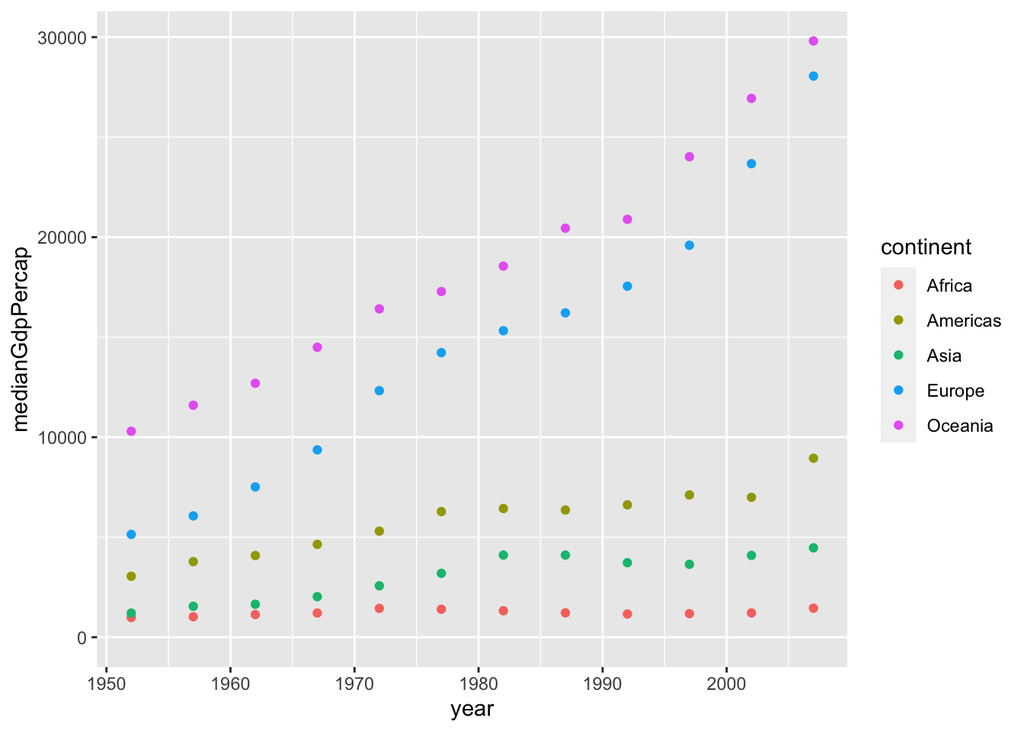

```r
# Plot the change in medianGdpPercap in each continent over time
ggplot(by_year_continent,aes(x=year,y=medianGdpPercap,color=continent)) +
  geom_point() +
  expand_limits(y=0)
```

Another example

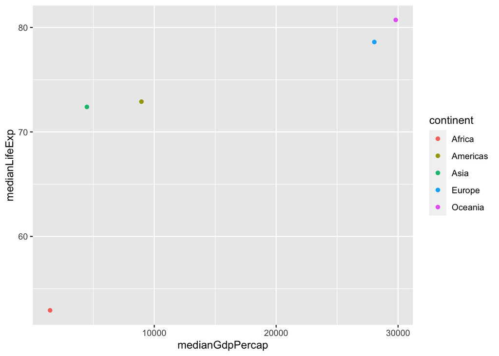

```r
# Summarize the median GDP and median life expectancy per continent in 2007
by_continent_2007<- gapminder %>%
  filter(year==2007) %>%
  group_by(continent) %>%
  summarize(medianLifeExp=median(lifeExp),
            medianGdpPercap=median(gdpPercap))

# Use a scatter plot to compare the median GDP and median life expectancy
ggplot(by_continent_2007,aes(x=medianGdpPercap,y=medianLifeExp,color=continent)) +
    geom_point()
```

##Types of Visualizations  
**bar plots**: good at comparing statistics for each of several categories.  
To create a bar plot, you use `geom_col()`, short for “column”. There are two aesthetics in a bar plot. X is the categorical variable, Y is the variable that determines the height of the bars.

**Notice that: the positions of `group_by` and `filter` don’t affect the data wrangling results.**

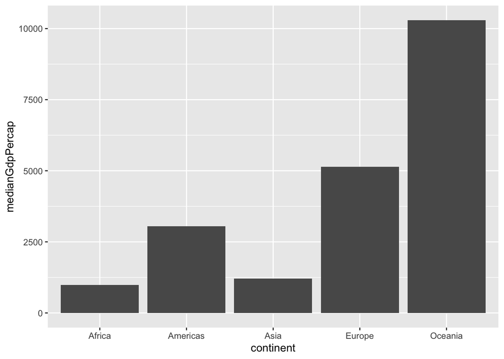

```r
#Visualizing median GDP per capita by continent
# Summarize the median gdpPercap by continent in 1952
by_continent<-gapminder %>%
  group_by(continent) %>%
  filter(year==1952)  %>%
  summarize(medianGdpPercap=median(gdpPercap))

# Create a bar plot showing medianGdp by continent
ggplot(by_continent,aes(x=continent,y=medianGdpPercap)) +
  geom_col()
```

```r
#Another example
#Visualizing GDP per capita by country in Oceania
# Filter for observations in the Oceania continent in 1952
oceania_1952<-gapminder %>% filter(continent=="Oceania", year==1952)
oceania_1952
```

```
## # A tibble: 2 × 6
##   country     continent  year lifeExp     pop gdpPercap
##   <fct>       <fct>     <int>   <dbl>   <int>     <dbl>
## 1 Australia   Oceania    1952    69.1 8691212    10040.
## 2 New Zealand Oceania    1952    69.4 1994794    10557.
```

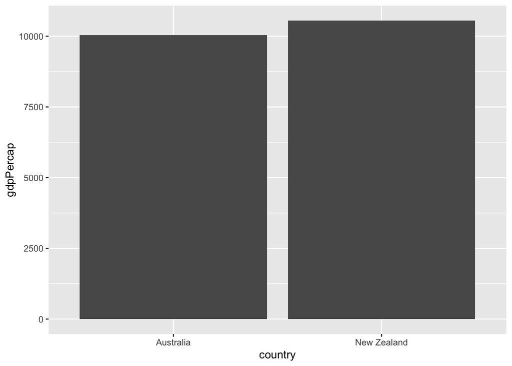

```r
# Create a bar plot of gdpPercap by country
ggplot(oceania_1952,aes(x=country,y=gdpPercap)) +
 geom_col()
```

**line plots**: visualizing changes over time.  
This makes it clearer that what we care about is the upward or downward trend over time. The way you make a line plot is to change one part of the code. `geom_point` was the part of the code that specified you were making a scatter plot. Simply change that to `geom_line` to make a line plot.

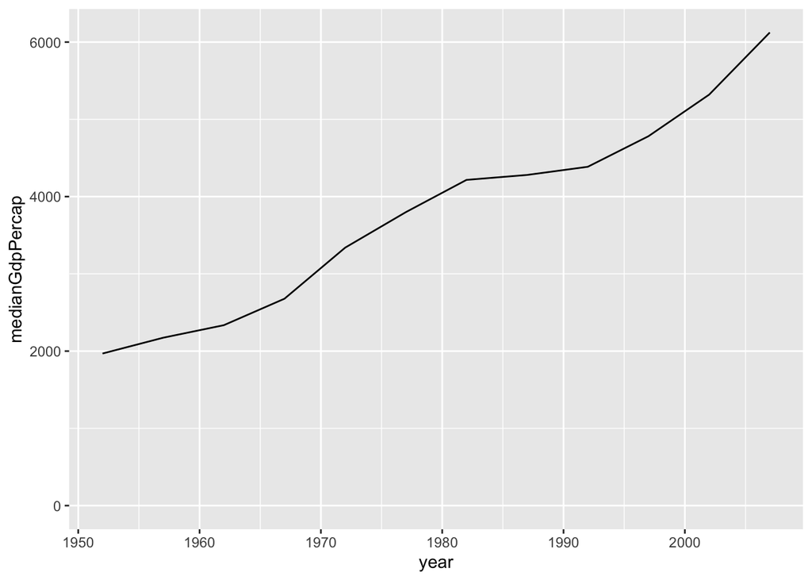

```r
#Visualizing median GDP per capita over time
# Summarize the median gdpPercap by year, then save it as by_year
by_year<- gapminder %>%
  group_by(year) %>%
  summarize(medianGdpPercap=median(gdpPercap))

# Create a line plot showing the change in medianGdpPercap over time
ggplot(by_year,aes(x=year,y=medianGdpPercap)) +
  geom_line() +
  expand_limits(y=0)
```

```r
#Visualizing median GDP per capita by continent over time
# Summarize the median gdpPercap by year & continent, save as by_year_continent
by_year_continent<-gapminder %>%
 group_by(year,continent) %>%
 summarize(medianGdpPercap=median(gdpPercap))
```

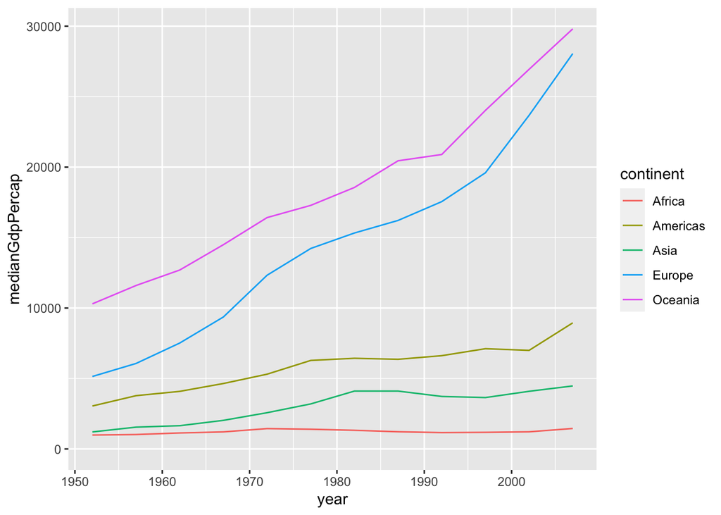

```r
# Create a line plot showing the change in medianGdpPercap by continent over time
ggplot(by_year_continent,aes(x=year,y=medianGdpPercap,color=continent)) +
 geom_line() +
 expand_limits(y=0)
```

**histograms**: which describe the distribution of a one-dimensional numeric variable.

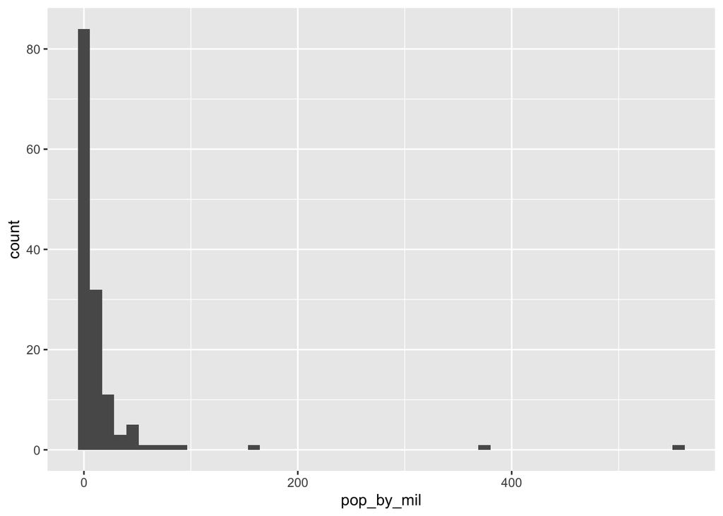

```r
#Visualizing the population
gapminder_1952 <- gapminder %>%
  filter(year == 1952) %>%
  mutate(pop_by_mil = pop / 1000000)

# Create a histogram of population (pop_by_mil)
ggplot(gapminder_1952,aes(x=pop_by_mil)) +
#set the number of bins to 50
  geom_histogram(bins=50)
```

```r
#also can set "binwidth" parameter within the geom_histogram
```

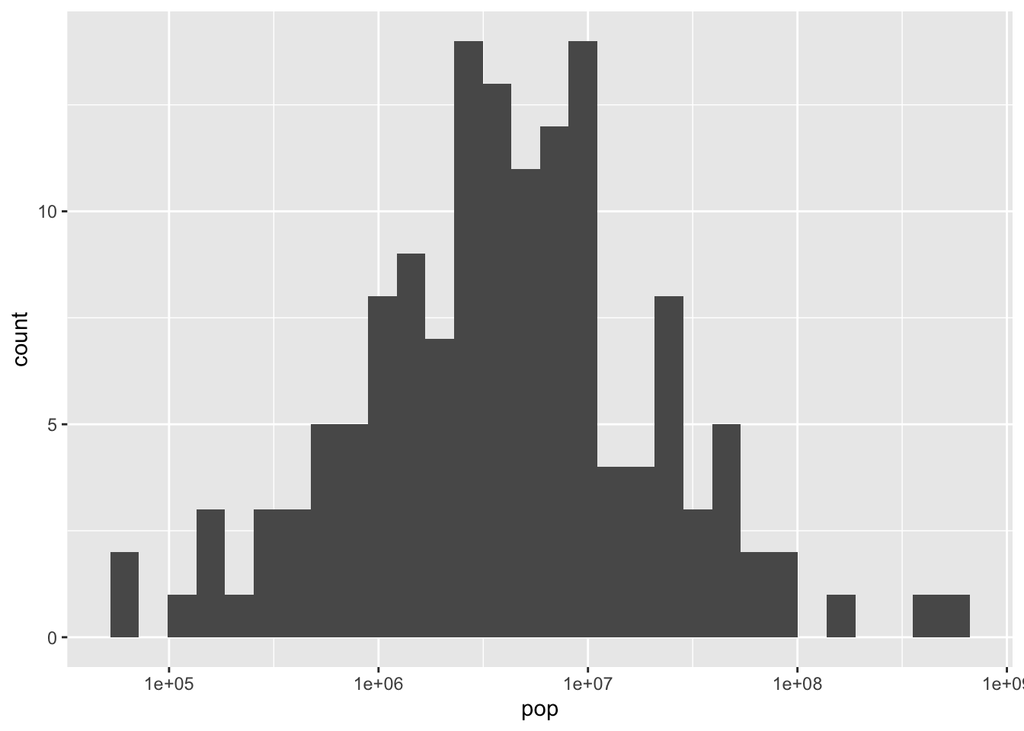

```r
#log scale
gapminder_1952 <- gapminder %>%
  filter(year == 1952)
# Create a histogram of population (pop), with x on a log scale
ggplot(gapminder_1952,aes(x=pop)) +
 scale_x_log10()+
  geom_histogram()
```

**box plots**: which compare the distribution of a numeric variable among several categories.  
(A boxplot helps give more context to the shape of the earlier histogram)

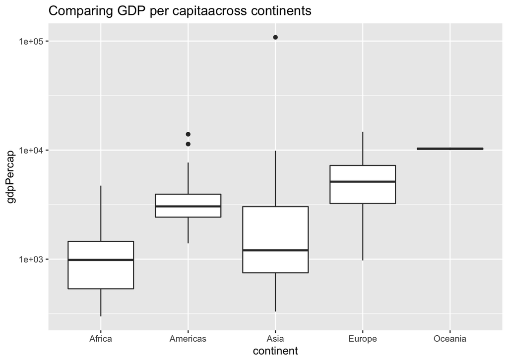

```r
#Comparing GDP per capita across continents
gapminder_1952 <- gapminder %>%
  filter(year == 1952)
# Create a boxplot comparing gdpPercap among continents
p<-ggplot(gapminder_1952,aes(x=continent,y=gdpPercap)) +
 geom_boxplot() +
 scale_y_log10()

# Add a title to this graph
p+ggtitle("Comparing GDP per capitaacross continents")
```